| Name | ANR | SNR | GIthub |
| --- | --- | --- | --- |
| 1. Guy Krekelberg | 739609 | 1257228 | https://github.com/Guykrekelberg/Assignment/blob/master/README.md |
| 2. Joost Melchers | 273612 | 1252062 | https://github.com/JoostMelchers/assignments/blob/master/README.md |
| 3. Miguel van de Goor | 332888 | 1256250 | https://github.com/miguelvdg/Assignments/blob/master/README.md |

Final Assignment Applied Economic Analysis 1 – Python Applied

# Questioning Google’s Search Engine Dominance

In our notebook we will illustrate how the market structure develops in a highly concentrated search engine market and whether a higher concentration will lead to diminishing welfare or not. By applying a contestable market model of Argenton & Prüfer (2012) we will be able to analytically and graphically show the different market structure developments and benefits.

This notebook page is mainly for educational purposes and could be referred to for policy analysis.

## Research Question.

How does welfare develop over time in differently structured search engine markets?

### Sub Question.

Does imposing perfect competition as a policy, concerning complete transparency of the installed database, improve innovation, search quality, consumer surplus, and total welfare?

## Table of Content

[output not shown]

## Motivation.

We all use it on a daily basis: a search engine. We rely on it. Our guess is that you make your search queries with Google, just like a majority of the world population. Google’s global market share for desktop use has been rising from 68 until 78 percent in 2016 alone, and in the mobile and tablet segment it has remained around a staggering 94 percent. These numbers tell us that Google has retrieved considerable market power and is close to monopolization. It is therefore not a surprise that European Commission has been investigating the tech giant. In a press release of July 2016 two statements have come forward:

> *“Google has abused its dominant position by systematically favouring its comparison shopping service in its search result pages”* and *“the company has abused its dominant position by artificially restricting the possibility of third party websites to display search advertisements from Google's competitors”*.

As you may have noticed, Google’s market power is under scrutiny and should be questioned. It is therefore of interest to see how it has developed until this point over time for it to make it understandable, but also to see how policies could influence market competition in benefit of consumers and total welfare.

## Method.

In order to show that the development in the search engine market is worrying, we solve the [Argenton & Prüfer model](https://pure.uvt.nl/ws/files/1373523/search_engines.pdf) for each possible competition level inside the market. The three levels we consider are the competitive triopoly, the non-competitive triopoly and the duopoly. Market shares, profits, producer surplus, consumer surplus and total welfare are computed. Then we will show which policy needs to be implemented in order to make the search engine market healthy again, and compare this possible policy implementation to the current situation. A reality check is done in order to prove how the market has been developing over time. At last, a senstivity analysis will be executed to show the effect of an increase in advertising revenue on the market conditions.

## Main Assumptions.

1. The advertising revenue of a search engine is proportional to its market share, which is broadly in line with industry’s figures. This is also supported with advertisers’ [reasoning](http://www.investopedia.com/articles/investing/060315/why-facebook-biggest-threat-googles-adrevenue-throne.asp) where the amount of visitors increases its demand.
2. Consumers can only rationally expect search engine quality to be different on average, for they do not know which engine delivers the best quality for each query. Therefore the firm's market share is monotonically increasing in its perceived average search quality.
3. There is a unit mass of consumers, each of which has demand for one query, and the cost for a consumers to use a search engine is zero.
4. Moreover, the quality is high enough such that everyone will use a search engine, meaning that the market is fully covered.

# Model

### Importing libraries and packages

```python
import math
import numpy as np
import pandas as pd
from scipy import optimize,arange
from numpy import array

import matplotlib.pyplot as plt

%matplotlib inline
```

### Introducing Model Characteristics

$x_i$ = the simultaneous search quality of firm $i$

$N_i$ = the installed base of firm $i$, in other words it is the amound of previous search queries run

$F$ = the fixed cost for operations

$p$ = the exogenously given advertising revenue associated to one consumer

$D_i = \frac{x_i}{\sum_{i=1}^{n} x_i}$ = the market share of firm $i$

$C(x_i) = \frac{x_i}{N_i}$ = the costs of production of quality $x_i$

The maximization problem each firm will solve is the following:

$\underset{x_i}{\text{max}} \hspace{10pt} \Pi_i = \frac{x_i}{\sum_{i=1}^{n} x_i}p - \frac{x_i}{N_i} - F$

## The Triopoly Case

Since the search engine market is a triopoly at first, where the model is a static game with complete information, the (Nash) Equilibrium values are obtained by solving the set of reaction functions $x_i(p, N, \sum{x_j})$. Where the equilibrium values $x_i^*$ are as follows:

$ \begin{align} x_1 & = \sqrt{pN_1(x_2 + x_3)} - x_2 - x_3 && x_2 = \sqrt{pN_2(x_1 + x_3)} - x_1 - x_3 &&& x_3 = \sqrt{p(x_1 + x_2)} - x_1 - x_2 \\ x_1^* & = \sqrt{\frac{p^2N^2_1N^2_2}{(N_2+N_1(1+N_2))^2}} - \frac{4pN_1N^2_2}{(N_2+N_1(1+N_2))^2} && x_2^* = \frac{2pN_1N_2(N_1(N_2-1)+N_2)}{(N_2+N_1(1+N_2))^2} &&& x_3^* = \frac{2pN_1N_2(-N_1(N_2-1)+N_2)}{(N_2+N_1(1+N_2))^2}\\ \end{align} $

The python code to show the development of $x_i^*$ over $N_1$ is plotted below, where $N_2$ is taken as a constant *($N_3$ is irrelevant for the equilibrium)*, $p$ is set to 1 and fixed costs are considered nil:

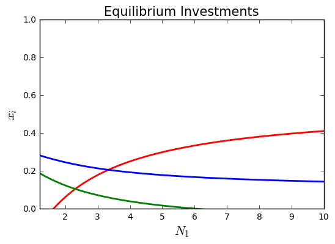

```python
def investment_trio_1 (N_1, N_2, p):
    return (((p**2)*(N_1)**2*(N_2)**2)/(N_2+N_1*(1+N_2))**2)**(1/2)- (4*p*N_1*N_2**2)/((N_2+N_1*(1+N_2))**2)
def investment_trio_2 (N_1, N_2, p):
    return 2*p*N_1*N_2*(N_1*(N_2-1)+N_2)/((N_2+N_1*(1+N_2))**2)
def investment_trio_3 (N_1, N_2, p):
    return 2*p*N_1*N_2*(-N_1*(N_2-1)+N_2)/((N_2+N_1*(1+N_2))**2)

N_2 = 1.2 ## just an example (same as in paper)
p = 1.0
F=0

range_N_1 = arange(1.20,10.1,0.1)

range_investment_trio_1= [investment_trio_1 (N_1, N_2, p) for N_1 in range_N_1]
range_investment_trio_2= [investment_trio_2 (N_1, N_2, p) for N_1 in range_N_1]
range_investment_trio_3= [investment_trio_3 (N_1, N_2, p) for N_1 in range_N_1]


plt.clf()
plt.plot(range_N_1,range_investment_trio_1,'-', color = 'r', linewidth = 2)
plt.plot(range_N_1,range_investment_trio_2,'-', color = 'b', linewidth = 2)
plt.plot(range_N_1,range_investment_trio_3,'-', color = 'g', linewidth = 2)
plt.ylim (0.0, 1.0)
plt.xlim(1.2, 10.0)
plt.title("Equilibrium Investments",fontsize = 15)
plt.xlabel("$N_1$",fontsize = 15)
plt.ylabel("$x_i$",fontsize = 15,rotation = 90)
```

The market shares $D_i^* = \frac{x_i^*}{\sum_{i=1}^{n} x_i^*}$ develop the same way as $x_i^*$, since recall that the market share is monotonically increasing in its perceived average search quality. The Nash equilibrium market shares are:

$ \begin{align} & D_1^* = 1 - \frac{2N_2}{N_2 + N_1(1+N_2)} && D_2^* = 1 - \frac{2N_1}{N_2 + N_1(1+N_2)} &&& D_3^* = \frac{N_1(1-N_2)+N_2}{N_2+N_1(1+N_2)} \end{align} $

In Python code, this translates to the following, where we use the same trick but different functions:

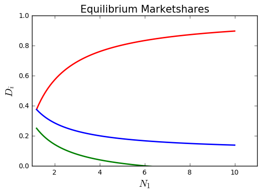

```python
def marketshare_1(N_1,N_2):
    return (1-(2*N_2)/(N_2+N_1*(1+N_2)))
def marketshare_2(N_1,N_2):
    return (1-(2*N_1)/(N_2+N_1*(1+N_2)))
def marketshare_3(N_1,N_2):
    return (N_1*(1-N_2)+N_2)/(N_2+N_1*(1+N_2))


range_marketshare_1= [marketshare_1 (N_1,N_2) for N_1 in range_N_1]
range_marketshare_2= [marketshare_2 (N_1,N_2) for N_1 in range_N_1]
range_marketshare_3= [marketshare_3 (N_1,N_2) for N_1 in range_N_1]

plt.clf()
plt.plot(range_N_1,range_marketshare_1,'-', color = 'r', linewidth = 2)
plt.plot(range_N_1,range_marketshare_2,'-', color = 'b', linewidth = 2)
plt.plot(range_N_1,range_marketshare_3,'-', color = 'g', linewidth = 2)
plt.ylim (0.0, 1.0)
plt.title("Equilibrium Marketshares",fontsize = 15)
plt.xlabel("$N_1$",fontsize = 15)
plt.ylabel("$D_i$",fontsize = 15,rotation = 90)
```

Also in the market shares values we notice firm 3 leaving the market, due to their continuous decrease of search quality due to the loss of their installed base. Firm 2 still survives, but as we will see in the duopoly case, the situation and optimization problems are altered due to the different market structure. Furthermore, the dominance of firm 1 becomes more and more apparent.

Now that we have determined $D_i^*$ and $x_i*$, and for a given $N_1$, $N_2$, $F$, and $p$, we can determine and plot the equilibrium profits as given at the Model Characteristics. We get:

$ \begin{align} & \Pi_1^* = \frac{(N_2-N_1(1+N_2))^2}{(N_2+N_1(1+N_2))^2}p-F && \Pi_2^* = \frac{(N_2+N_1(N_2-1))^2}{(N_2+N_1(1+N_2))^2}p-F &&& \Pi_3^* = \frac{(N_2+N_1(1-N_2))^2}{(N_2+N_1(1+N_2))^2}p-F \end{align} $

In Python code the plot of equilibrium profits over $N_1$ is obtained as follows:

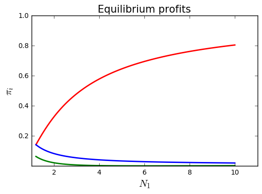

```python
def profit_1(N_1,N_2,p,F):
    return ((N_2-N_1*(1+N_2))**2)/(N_2+N_1*(1+N_2))**2*p-F
def profit_2(N_1,N_2,p,F):
    return ((N_2+N_1*(N_2-1))**2)/(N_2+N_1*(1+N_2))**2*p-F
def profit_3(N_1,N_2,p,F):
    return ((N_2+N_1*(1-N_2))**2)/(N_2+N_1*(1+N_2))**2*p-F


range_profit_1= [profit_1(N_1,N_2,p,F) for N_1 in range_N_1]
range_profit_2= [profit_2(N_1,N_2,p,F) for N_1 in range_N_1]
range_profit_3= [profit_3(N_1,N_2,p,F) for N_1 in range_N_1]

plt.clf()
plt.plot(range_N_1,range_profit_1,'-', color = 'r', linewidth = 2)
plt.plot(range_N_1,range_profit_2,'-', color = 'b', linewidth = 2)
plt.plot(range_N_1,range_profit_3,'-', color = 'g', linewidth = 2)
plt.ylim (0.00000001, 1.0)
plt.title("Equilibrium profits",fontsize = 15)
plt.xlabel("$N_1$",fontsize = 15)
plt.ylabel("$\pi_i$",fontsize = 15,rotation = 90)
```

Just like in the previous two graphs, we notice the same divergence, but then in profits. Firm 1 clearly benefits from their market share increase and firm 2 and 3 suffer. Yet again, firm 2 manages to keep making a small amount of profits.

However, to see whether the modelled development in a triopoly case benefits society, besides only firms' profits, we will have a look at welfare and distinguish between producer and consumer surplus, where welfare = producer surplus + consumer surplus:

$ Producer \, Surplus = \Pi_1 + \Pi_2 + \Pi_3 = \dfrac{(3N_2^2 - 2N_1N_2(1+N_2)+N_1^2(3+N_2(3N_2-2)))}{N_2+N_1(1+N_2))^2}p-3F $

$ Consumer \, Surplus = D_1x_1^*+D_2x_2^*+D_3x_3^* = \dfrac{2N_1N_2(3N_2^2-2N_1N_2(1+N_2)+N_1^2(3+N_2(3N_2-2))}{N_2+N_1(1+N_2))^3}p $

$ Welfare = PS + CS = \dfrac{(N_2+N_1(3N_2+1))(3N_2^2-2N_1N_2(1+N_2)+N_1^2(3+N_2(3N_2-2))}{N_2+N_1(1+N_2))^3}p-3F $

Solving for these equations over N translates into the following code and graph:

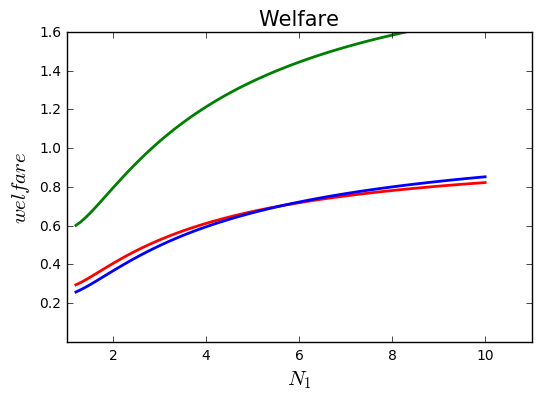

```python
##Welfare

def producersurplus_triopoly(N_1,N_2,p,F):
    return ((3*N_2-2*N_1*N_2*(1+N_2)+N_1**2*(3+N_2*(3*N_2-2)))*p/(N_2+N_1*(1+N_2))**2-3*F)

def consumersurplus_triopoly(N_1,N_2,p):
    return (2*N_1*N_2*(3*N_2**2-2*N_1*N_2*(1+N_2)+N_1**2*(3+N_2*(3*N_2-2))))*p/(N_2+N_1*(1+N_2))**3

def welfare_triopoly(N_1,N_2,p,F):
    return (((N_2+N_1*(3*N_2+1))*(3*(N_2**2)-2*N_1*N_2*(1+N_2)+(N_1**2)*(3+N_2*(3*N_2-2)))*p)/(N_2+N_1*(1+N_2))**3)-3*F

range_PS= [producersurplus_triopoly(N_1,N_2,p,F) for N_1 in range_N_1]
range_CS= [consumersurplus_triopoly(N_1,N_2,p) for N_1 in range_N_1]
range_Welfare= [welfare_triopoly(N_1,N_2,p,F) for N_1 in range_N_1]


plt.clf()
plt.plot(range_N_1,range_PS,'-', color = 'r', linewidth = 2)
plt.plot(range_N_1,range_CS,'-', color = 'b', linewidth = 2)
plt.plot(range_N_1,range_Welfare,'-', color = 'g', linewidth = 2)
plt.ylim (0.00000001, 1.6)
plt.title("Welfare",fontsize = 15)
plt.xlabel("$N_1$",fontsize = 15)
plt.ylabel("$welfare$",fontsize = 15,rotation = 90)
```

Fortunately, besides increasing profits, the consumer surplus isn't harmed and increases with $N_1$. The welfare is increasing as the market structure develops and shows that society will benefit in the triopoly cases with the current market architecture. What is interesting to see is that consumer surplus overtakes producer surplus at around $N_1 = 6$, which you wouldn't expect since Firm 1 gains market share and market power and should be able to accrue more of the benefits to themselves. An explanation is that the loss of profits from the other firms is more than what firm 1 gains. However the story isn't finished, since a triopoly is not sustainable and we move on to the duopoly case as shown in the graph portraying the market shares.

# The Duopoly Case

Over time in the triopoly case, a firm will not be able to compete anymore and make profits. In that instance he will leave the market and a duopoly scenario exists. In this part we will graphically show what happens in the duopoly case. The model assumptions, characteristics and profit maximization problem remain untouched, however there will only be two reaction function to solve for the Nash Equilibrium $x_i^*$ and $D_I^*$:

$ \begin{align} & x_1^* = \frac{N_1^2}{(1+N_1)^2} && x_2^* = \frac{N_1}{(1+N_1)^2} \\ & D_1^* = \frac{N_1}{1+N_1} && D_2^* = \frac{1}{1+N_1} \end{align} $

This is codified in the following manner:

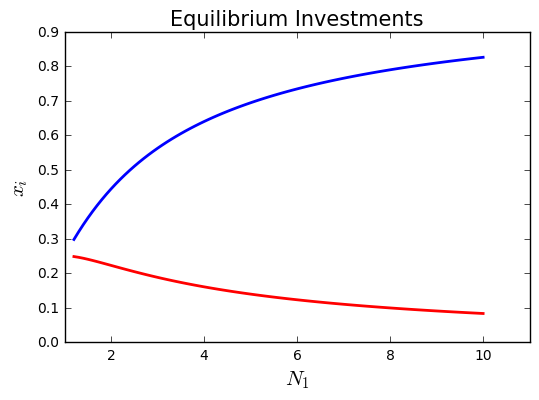

```python
## duopoly
def investment_reaction_function (N_1):
    return (N_1**2)/(1+N_1)**2
def investment_reaction_2(N_1):
    return N_1/(1+N_1)**2

range_N_1 = arange(1.20,10.1,0.1)
range_investment_reaction_function_1= [investment_reaction_function(N_1) for N_1 in range_N_1]
range_investment_reaction_2= [investment_reaction_2(N_1) for N_1 in range_N_1]

plt.clf()
plt.plot(range_N_1,range_investment_reaction_2,'-', color = 'r', linewidth = 2)
plt.plot(range_N_1,range_investment_reaction_function_1,'-', color = 'b', linewidth = 2)
plt.title("Equilibrium Investments",fontsize = 15)
plt.xlabel("$N_1$",fontsize = 15)
plt.ylabel("$x_i$",fontsize = 15,rotation = 90)
```

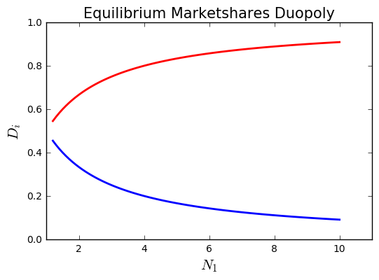

```python
def marketshare_duo_1(N_1):
    return (N_1)/(1+N_1)
def marketshare_duo_2(N_1):
    return (1/(N_1+1))


range_marketshare_duo_1= [marketshare_duo_1(N_1) for N_1 in range_N_1]
range_marketshare_duo_2= [marketshare_duo_2(N_1) for N_1 in range_N_1]


plt.clf()
plt.plot(range_N_1,range_marketshare_duo_1,'-', color = 'r', linewidth = 2)
plt.plot(range_N_1,range_marketshare_duo_2,'-', color = 'b', linewidth = 2)
plt.ylim (0.0, 1.0)
plt.title("Equilibrium Marketshares Duopoly",fontsize = 15)
plt.xlabel("$N_1$",fontsize = 15)
plt.ylabel("$D_i$",fontsize = 15,rotation = 90)
```

In the same way as in the Triopoly Case, we can obtain the equilibrium profits given $x_i^*$ and $D_i^*$ with substitution: $ \Pi_1 = \frac{N_1^2}{(1+N_1)^2}-F ,\hspace{40pt} \Pi_2 = \frac{1}{(1+N_1)^2}-F $

The graph is produced by the following:

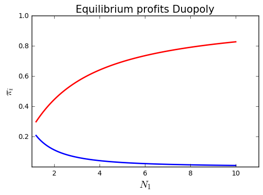

```python
def profit_duo_1(N_1,F):
    return ((N_1)**2)/(1+N_1)**2-F
def profit_duo_2(N_1,F):
    return 1/(1+N_1)**2-F

range_N_1 = arange(1.20,10.1,0.1)

range_profit_duo_1= [profit_duo_1(N_1,F) for N_1 in range_N_1]
range_profit_duo_2= [profit_duo_2(N_1,F) for N_1 in range_N_1]

plt.clf()
plt.plot(range_N_1,range_profit_duo_1,'-', color = 'r', linewidth = 2)
plt.plot(range_N_1,range_profit_duo_2,'-', color = 'b', linewidth = 2)
plt.ylim (0.00000001, 1.0)
plt.title("Equilibrium profits Duopoly",fontsize = 15)
plt.xlabel("$N_1$",fontsize = 15)
plt.ylabel("$\pi_i$",fontsize = 15,rotation = 90)
```

If we then have a look at the total welfare, producer surplus and consumer surplus, we can see whether a duopoly case is beneficial over time. The equations that hold are:

$ Producer \, Surplus = \dfrac{N_1^2+1}{(1+N_1)^2}-2F $

$ Consumer \, Surplus = \dfrac{N_1+N_1^3}{(1+N_1)^3} $

$ Total \, Welfare = \dfrac{1+2N_1+N_1^2+2N_1^3}{(1+N_1)^3}-2F $

Computed in Python by:

```python
##Welfare

def producersurplus_duopoly(N_1,F):
    return (N_1**2+1)/(1+N_1)**2-2*F

def consumersurplus_duopoly(N_1):
    return (N_1+N_1**3)/(1+N_1)**3

def welfare_duopoly(N_1, F):
    return (1+2*N_1+N_1**2+2*N_1**3)/(1+N_1)**3-2*F

range_PS_duo= [producersurplus_duopoly(N_1,F) for N_1 in range_N_1]
range_CS_duo= [consumersurplus_duopoly(N_1) for N_1 in range_N_1]
range_Welfare_duo= [welfare_duopoly(N_1,F) for N_1 in range_N_1]


plt.clf()
plt.plot(range_N_1,range_PS_duo,'-', color = 'r', linewidth = 2)
plt.plot(range_N_1,range_CS_duo,'-', color = 'b', linewidth = 2)
plt.plot(range_N_1,range_Welfare_duo,'-', color = 'g', linewidth = 2)
plt.ylim (0.00000001, 1.6)
plt.title("Welfare",fontsize = 15)
plt.xlabel("$N_1$",fontsize = 15)
plt.ylabel("$welfare$",fontsize = 15,rotation = 90)
```

[output not shown]

[output not shown]

# Policy Recommendation

In contrast to the previous cases, in which $N_i \neq N_j$, the policy which is recommended is that the query logs amongst all search engines are shared such that $N_1 = N_j$. That is, the installed bases are equal and we have $N = N_1 + N_2 + N_3$. This situation is dubbed a Competitive Triopoly, since the tipping of the market is not due to the differences in installed bases anymore. The market has become competitive in $x_i$ only.

The Nash Equilibrium values for the quality level is: $x_1^* = x_2^* = x_3^* = \tfrac{2}{9}Np = x^{competitive}$. Where this results in equal market share of one-third for each. The equilibrium profits, consumer surplus, producer surplus and welfare are given as:

$\Pi_1 = \Pi_2 = \Pi_3 = \tfrac{p}{9}-F $

$Producer \, Surplus = \tfrac{p}{3} - 3F $

$Consumer \, Surplus = \tfrac{2}{9}Np $

$and \, Welfare = \tfrac{p}{9}(3+2N)-3F $

The graphs of Quality Levels/Equilibrium Investments and that of Welfare have been computed and shown below:

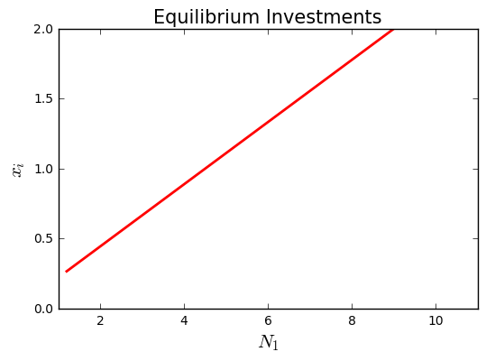

```python
def investment_triopoly(N_1,p):
    return (2.0/9*N_1*p)

range_investment_triopoly= [investment_triopoly(N_1,p) for N_1 in range_N_1]

plt.clf()
plt.plot(range_N_1,range_investment_triopoly,'-', color = 'r', linewidth = 2)
plt.ylim (0.0, 2.0)
plt.title("Equilibrium Investments",fontsize = 15)
plt.xlabel("$N_1$",fontsize = 15)
plt.ylabel("$x_i$",fontsize = 15,rotation = 90)
```

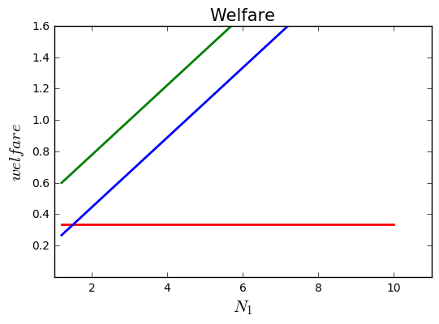

```python
def producersurplus_comp_triopoly(p,F):
    return p*(1.0/3)- 3*F

def consumersurplus_comp_triopoly(N_1,p):
    return (2.0/9)*N_1*p

def welfare_comp_triopoly(N_1,p,F):
    return p*(1.0/9)*(3+2*N_1)-3*F


range_PS_comp_trio= [producersurplus_comp_triopoly(p,F) for N_1 in range_N_1]
range_CS_comp_trio= [consumersurplus_comp_triopoly(N_1,p) for N_1 in range_N_1]
range_Welfare_comp_trio= [welfare_comp_triopoly(N_1,p,F) for N_1 in range_N_1]


plt.clf()
plt.plot(range_N_1,range_PS_comp_trio,'-', color = 'r', linewidth = 2)
plt.plot(range_N_1,range_CS_comp_trio,'-', color = 'b', linewidth = 2)
plt.plot(range_N_1,range_Welfare_comp_trio,'-', color = 'g', linewidth = 2)
plt.ylim (0.00000001, 1.6)
plt.title("Welfare",fontsize = 15)
plt.xlabel("$N_1$",fontsize = 15)
plt.ylabel("$welfare$",fontsize = 15,rotation = 90)
```

# Comparison:

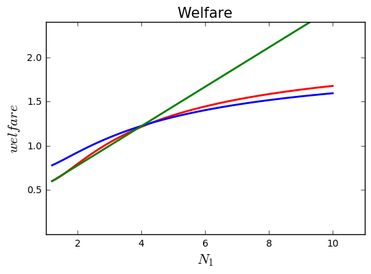

```python
plt.clf()
plt.plot(range_N_1,range_Welfare,'-', color = 'r', linewidth = 2)
plt.plot(range_N_1,range_Welfare_duo,'-', color = 'b', linewidth = 2)
plt.plot(range_N_1,range_Welfare_comp_trio,'-', color = 'g', linewidth = 2)
plt.ylim (0.00000001, 2.4)
plt.title("Welfare",fontsize = 15)
plt.xlabel("$N_1$",fontsize = 15)
plt.ylabel("$welfare$",fontsize = 15,rotation = 90)
```

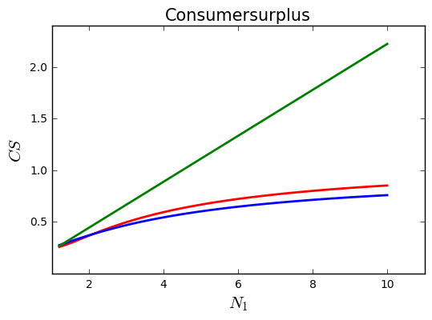

```python
plt.clf()
plt.plot(range_N_1,range_CS,'-', color = 'r', linewidth = 2)
plt.plot(range_N_1,range_CS_duo,'-', color = 'b', linewidth = 2)
plt.plot(range_N_1,range_CS_comp_trio,'-', color = 'g', linewidth = 2)
plt.ylim (0.00000001, 2.4)
plt.title("Consumersurplus",fontsize = 15)
plt.xlabel("$N_1$",fontsize = 15)
plt.ylabel("$CS$",fontsize = 15,rotation = 90)
```

[figure not shown]

```python
plt.clf()
plt.plot(range_N_1,range_investment_trio_1,'-', color = 'r', linewidth = 2)
plt.plot(range_N_1,range_investment_reaction_2,'-', color = 'b', linewidth = 2)
plt.plot(range_N_1,range_investment_triopoly,'-', color = 'g', linewidth = 2)
plt.ylim (0.00000001, 2.4)
plt.title("Investments of Leader",fontsize = 15)
plt.xlabel("$N_1$",fontsize = 15)
plt.ylabel("$x_1$",fontsize = 15,rotation = 90)
```

## Reality check:

```python
import plotly.plotly as py
py.sign_in('guykrekelberg', 'AG1fi4HfEZ3yhpDSuHiK')
from plotly.graph_objs import *
import plotly.tools as tls
import plotly.graph_objs as go
```

One can find the data here (link)

Link naar data 1: http://gs.statcounter.com/search-engine-market-share/all/united-states-of-america/2009

Link naar data 2: http://data.okfn.org/data/rgrp/search-engine-market-shares

```python
df = pd.read_csv("marketshareoudnieuw.csv", \
                 sep=';',skipinitialspace=True, header = 0)
```

```python
Google = go.Scatter(x=df['Date'], y=df['Google'], mode='lines', name='Google')
Yahoo = go.Scatter(x=df['Date'], y=df['Yahoo!'], mode='lines', name='Yahoo!' )
Bing = go.Scatter(x=df['Date'], y=df['MSN+bing'], mode='lines', name='MSN+Bing')
Others = go.Scatter(x=df['Date'], y=df['Others'], mode='lines', name='Others')


layout = Layout(
    title='Search Engine Market US',
    xaxis=XAxis(
        title='Time',
        titlefont=Font(
            family='Courier New, monospace',
            size=18,
            color='#7f7f7f'
        )
    ),
    yaxis=YAxis(
        title='Market share (%)',
        titlefont=Font(
            family='Courier New, monospace',
            size=18,
            color='#7f7f7f'
        )
    )
)

fig = go.Figure(data=[Google, Yahoo, Bing, Others], layout = layout)


py.iplot(fig, filename='US market for SE')
```

[interactive chart not shown]

# Sensativity Analysis

We conduct a sensitivity analysis. We will check whether the predictions of the model will change or hold if we increase the revenues of advertisements (p). In the assymetric triopoly case.

[figure not shown]

```python
def investment_trio_1 (N_1, N_2, p):
    return (((p**2)*(N_1)**2*(N_2)**2)/(N_2+N_1*(1+N_2))**2)**(1/2)- (4*p*N_1*N_2**2)/((N_2+N_1*(1+N_2))**2)
def investment_trio_2 (N_1, N_2, p):
    return 2*p*N_1*N_2*(N_1*(N_2-1)+N_2)/((N_2+N_1*(1+N_2))**2)
def investment_trio_3 (N_1, N_2, p):
    return 2*p*N_1*N_2*(-N_1*(N_2-1)+N_2)/((N_2+N_1*(1+N_2))**2)

N_2 = 1.2 ## just an example (same as in paper)
p = 2.0
F=0

range_N_1 = arange(1.20,10.1,0.1)

range_investment_trio_1= [investment_trio_1 (N_1, N_2, p) for N_1 in range_N_1]
range_investment_trio_2= [investment_trio_2 (N_1, N_2, p) for N_1 in range_N_1]
range_investment_trio_3= [investment_trio_3 (N_1, N_2, p) for N_1 in range_N_1]


plt.clf()
plt.plot(range_N_1,range_investment_trio_1,'-', color = 'r', linewidth = 2)
plt.plot(range_N_1,range_investment_trio_2,'-', color = 'b', linewidth = 2)
plt.plot(range_N_1,range_investment_trio_3,'-', color = 'g', linewidth = 2)
plt.ylim (0.0, 1.0)
plt.title("Equilibrium Investments",fontsize = 15)
plt.xlabel("$N_1$",fontsize = 15)
plt.ylabel("$x_i$",fontsize = 15,rotation = 90)
```

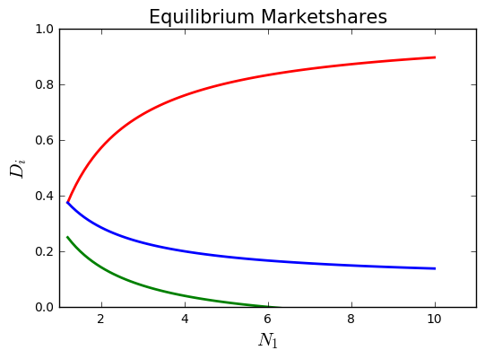

```python
def marketshare_1(N_1,N_2):
    return (1-(2*N_2)/(N_2+N_1*(1+N_2)))
def marketshare_2(N_1,N_2):
    return (1-(2*N_1)/(N_2+N_1*(1+N_2)))
def marketshare_3(N_1,N_2):
    return (N_1*(1-N_2)+N_2)/(N_2+N_1*(1+N_2))


range_marketshare_1= [marketshare_1 (N_1,N_2) for N_1 in range_N_1]
range_marketshare_2= [marketshare_2 (N_1,N_2) for N_1 in range_N_1]
range_marketshare_3= [marketshare_3 (N_1,N_2) for N_1 in range_N_1]

plt.clf()
plt.plot(range_N_1,range_marketshare_1,'-', color = 'r', linewidth = 2)
plt.plot(range_N_1,range_marketshare_2,'-', color = 'b', linewidth = 2)
plt.plot(range_N_1,range_marketshare_3,'-', color = 'g', linewidth = 2)
plt.ylim (0.0, 1.0)
plt.title("Equilibrium Marketshares",fontsize = 15)
plt.xlabel("$N_1$",fontsize = 15)
plt.ylabel("$D_i$",fontsize = 15,rotation = 90)
```

[figure not shown]

```python
def profit_1(N_1,N_2,p,F):
    return ((N_2-N_1*(1+N_2))**2)/(N_2+N_1*(1+N_2))**2*p-F
def profit_2(N_1,N_2,p,F):
    return ((N_2+N_1*(N_2-1))**2)/(N_2+N_1*(1+N_2))**2*p-F
def profit_3(N_1,N_2,p,F):
    return ((N_2+N_1*(1-N_2))**2)/(N_2+N_1*(1+N_2))**2*p-F

range_profit_1= [profit_1(N_1,N_2,p,F) for N_1 in range_N_1]
range_profit_2= [profit_2(N_1,N_2,p,F) for N_1 in range_N_1]
range_profit_3= [profit_3(N_1,N_2,p,F) for N_1 in range_N_1]

plt.clf()
plt.plot(range_N_1,range_profit_1,'-', color = 'r', linewidth = 2)
plt.plot(range_N_1,range_profit_2,'-', color = 'b', linewidth = 2)
plt.plot(range_N_1,range_profit_3,'-', color = 'g', linewidth = 2)
plt.ylim (0.00000001, 4.0)
plt.title("Equilibrium profits",fontsize = 15)
plt.xlabel("$N_1$",fontsize = 15)
plt.ylabel("$\pi_i$",fontsize = 15,rotation = 90)
```

[figure not shown]

```python
##Welfare

def producersurplus_triopoly(N_1,N_2,p,F):
    return ((3*N_2-2*N_1*N_2*(1+N_2)+N_1**2*(3+N_2*(3*N_2-2)))*p/(N_2+N_1*(1+N_2))**2-3*F)

def consumersurplus_triopoly(N_1,N_2,p):
    return (2*N_1*N_2*(3*N_2**2-2*N_1*N_2*(1+N_2)+N_1**2*(3+N_2*(3*N_2-2))))*p/(N_2+N_1*(1+N_2))**3

def welfare_triopoly(N_1,N_2,p,F):
    return (((N_2+N_1*(3*N_2+1))*(3*(N_2**2)-2*N_1*N_2*(1+N_2)+(N_1**2)*(3+N_2*(3*N_2-2)))*p)/(N_2+N_1*(1+N_2))**3)-3*F

range_PS= [producersurplus_triopoly(N_1,N_2,p,F) for N_1 in range_N_1]
range_CS= [consumersurplus_triopoly(N_1,N_2,p) for N_1 in range_N_1]
range_Welfare= [welfare_triopoly(N_1,N_2,p,F) for N_1 in range_N_1]


plt.clf()
plt.plot(range_N_1,range_PS,'-', color = 'r', linewidth = 2)
plt.plot(range_N_1,range_CS,'-', color = 'b', linewidth = 2)
plt.plot(range_N_1,range_Welfare,'-', color = 'g', linewidth = 2)
plt.ylim (0.00000001, 8)
plt.title("Welfare",fontsize = 15)
plt.xlabel("$N_1$",fontsize = 15)
plt.ylabel("$welfare$",fontsize = 15,rotation = 90)
```